# Session 08: Is partisanship a social identity, or a cue about ideology?

Tristan Muno

November 11, 2026

## Course evaluation

Please take **five minutes now** for the course evaluation.

- The link is in your **email**
- Most useful: what should I **keep**, and what should I **change**?

Thank you!

## Session 08 goals

First, we close **session 07, goal 4**: social identity complexity.

By the end of today, you will be able to:

1. State the party-over-policy and the policy-over-party positions and the evidence each rests on.
2. Explain why identity and categorisation are hard to separate in survey and experimental designs.
3. Specify what evidence would distinguish the two accounts, and why it is hard to obtain.

## Today

1. **Part 1: Finishing session 07**
   - Social identity complexity (Roccas and Brewer 2002)
   - Harteveld (2021) in five lines
2. **Part 2: Party over policy, or policy over party?**
   - The problem
   - Pair task
   - Dias and Lelkes (2022)
   - Orr et al. (2023)
3. **Wrap-up**

# Part 1: Finishing session 07

## Four structures

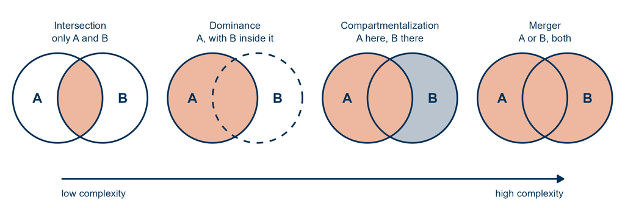

Figure 1: Four ways to represent two in-groups, A and B, with the in-group shaded. Intersection keeps only those in both, dominance keeps A and treats B as a feature of it, compartmentalization switches between A and B by context, and merger includes everyone in either. Complexity rises from left to right. Drawn after Roccas and Brewer (2002), Figure 1.

Table 1: The four structures, with the two examples Roccas and Brewer (2002) use themselves.

| Structure | A woman who is a lawyer | A migrant in a host society |
| --- | --- | --- |
| Intersection | Only women lawyers are “us” | Hyphenated: only my heritage, living here |
| Dominance | Lawyers are “us”, woman is a detail | Only the host culture, or only my own |
| Compartmentalization | Lawyer at the office, religion at home | One culture at work, the other at home |
| Merger | All lawyers and all women are “us” | Integrated: both cultures at once |

Complexity means seeing that one’s groups differ **and** reconciling them (Roccas and Brewer 2002, after Tetlock).

## Why complexity helps

- Someone who is “them” on one line is **“us”** on another
- No single group has to carry all of one’s belonging
- Disliking a group that contains friends feels **inconsistent**
- Complexity is lower under **stress** and **threat**, and where groups overlap in society
- First evidence: student surveys in the US and Israel, higher complexity goes with more **tolerance**, correlation only

## From person to society

1. Divides **line up** in society (social sorting)
2. People see their in-groups as **one** (low complexity)
3. Out-groups look homogeneous and different in every way
4. More **affective polarization**: warmer toward us, colder toward them

Shown for the US (Mason 2016). Does it travel?

## Harteveld (2021) in five lines

The magic five, one line each. Details are in the session 07 slides.

1. **Introduction**: does AP rise where political divides **align** with non-political ones, also outside the US?
2. **Theory**: infusion and complexity, so more social sorting should go with more AP, and the arrow may also run the other way
3. **Research design**: CSES, 119 elections in 40 countries, Cramér’s V and fixed effects, plus the Dutch LISS panel with a hybrid model
4. **Results**: within countries, **+0.37 SD** of AP per SD of sorting, nothing between countries, and people who come to fit their party better become more polarized
5. **Conclusion**: AP carries tensions from outside politics, but the evidence is observational and the categories are ascribed

# Part 2: Party over policy, or policy over party?

## The puzzle

Democrats and Republicans feel warmer toward their **own side** and colder toward **the other**. The question is why.

**Party over policy**

- Partisanship is a **social identity**
- I dislike them because they are **them**
- Session 4: social identity theory

**Policy over party**

- Partisanship is a **summary of positions**
- I dislike them because they **disagree** with me
- Session 3: ideological polarization

## Observational equivalence

- A **party** label tells you about **policy**: a Republican probably wants abortion restricted
- A **policy** position tells you about **party**: someone pro-life is probably a Republican
- “The issues are in party identification” (Fiorina, quoted in Dias and Lelkes (2022))

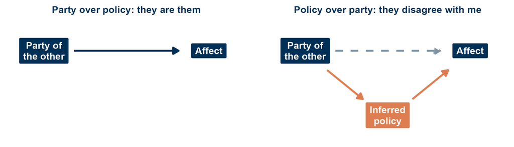

Figure 2: Two stories for one observation, a colder rating of an out-partisan. Left, party drives affect directly. Right, party only signals policy, and the observed link (dashed) runs through it.

**Important**

**As long as each signals the other, both accounts predict the same data.**

## Pair task

In pairs, four minutes. You run a vignette experiment: respondents read a short description of a person and rate them.

1. What do you vary at **random**?
2. What do you hold **constant**?
3. Which result would favour **party over policy**, and which **policy over party**?

## Exchange

**What we vary, what we hold constant**

**Which result favours which account**

# Dias and Lelkes (2022)

## Introduction

- Does **policy disagreement** or **partisan identity** drive interpersonal animus?
- Orr and Huber (2020): adding a policy position to a vignette cuts the party effect by **55 to 62%**
- Their reading: animus is mostly about policy
- Dias and Lelkes: those positions were **party branded**
- A branded position signals **identity** as well as substance
- So that design cannot tell the two accounts apart

## Theory

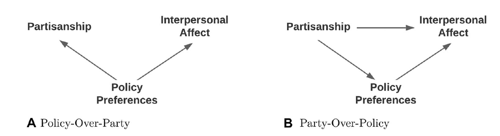

Figure 3: The two hypotheses as causal graphs. In A, policy preferences cause both partisanship and affect, so they confound the party effect. In B, partisanship shapes policy preferences, so they mediate it. *Source:* Dias and Lelkes (2022), Figure 1.

- Branded positions may also signal **loyalty**: a pro-life Democrat is a **disloyal** Democrat
- Critical test: does an **unbranded** position cut the party effect as much as a branded one?

## Research design

Table 2: The three main studies of Dias and Lelkes (2022). All experiments are preregistered. Studies 4 and 5 are robustness checks.

| Study | Sample | What it does |
| --- | --- | --- |
| 1 | 499 US adults, quota sample | Which of 35 issues do people tie to a party? Finds branded and unbranded issues of similar salience |
| 2 | 2,266 MTurk partisans, two waves | Vignettes vary party, whether a position is stated, and whether the issue is branded or unbranded |
| 3 | 1,799 MTurk partisans | Unbranded issues only, randomly **branded** by telling people where the parties stand, and positions loyal or disloyal |

- Outcomes: feeling thermometer, and social closeness (as a neighbour, marrying one’s child)
- The **party effect**: how much warmer a copartisan is rated than an out-partisan

## Results: Study 2

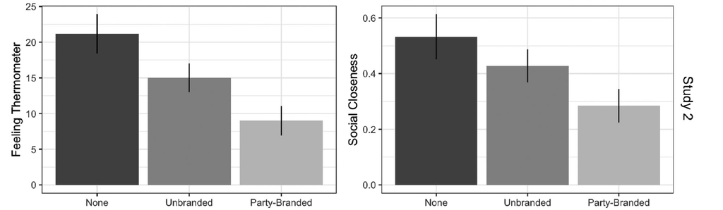

Figure 4: The party effect, how much warmer copartisans are rated than out-partisans, when the vignette states no policy, an unbranded policy or a party-branded policy. Thermometer (left) and social closeness (right). *Source:* Dias and Lelkes (2022), Figure 4, Panel A.

- No policy: **21** degrees warmer toward copartisans
- An unbranded policy cuts this by **29%**, a branded one by **57%**
- The gap is large for **strong** party identifiers, and not significant for weak ones

## Results: Study 3

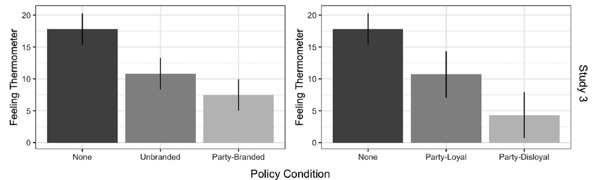

Figure 5: The party effect on the thermometer when the same unbranded issues are presented as unbranded or as branded (left), and when the branded position is loyal or disloyal to the person’s party (right). *Source:* Dias and Lelkes (2022), Figure 4, Panel C.

- The **same issues** in every condition, only the party label differs
- Branded cuts the party effect by **58%**, unbranded by **39%**
- **Disloyal** positions cut it by **76%**, loyal ones by **40%**

## Conclusion

- **Partisan identity** is the principal mechanism of AP
- Branded positions matter largely because they **signal identity**, above all disloyalty
- Policy still matters on its own: unbranded positions cut about **a third** of the party effect

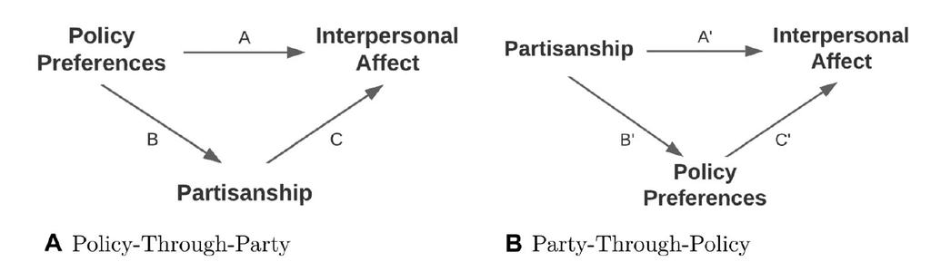

Figure 6: The revised model: policy through party (A) and party through policy (B). *Source:* Dias and Lelkes (2022), Figure 6.

What has to be true about “unbranded” for this test to work?

# Orr, Fowler and Huber (2023)

## Introduction

- Is AP driven by **identity**, **loyalty**, or **substance**?
- A reply to Dias and Lelkes (2022), by the authors of the study they criticised (Orr and Huber 2020)
- The claim: the Dias and Lelkes results are **exactly** what we expect if people care **only** about policy

## Theory: a simple model

**Note**

**The party effect we measure = caring about party itself + caring about policy × how much party tells you about policy.**

- Stating a policy position removes the second part, but **only for that one issue**
- **Branded** issue: party said a lot about it, so stating it removes a lot
- **Unbranded** issue: party said little about it, so stating it removes little

So a branded position shrinks the party effect more, **even if caring about party itself is zero**.

## The Elmer Fudd analogy

Elmer likes people who **hunt** and people who **eat rabbit**. He does not care about hats.

Table 3: The analogy of Orr et al. (2023, 953).

| In the analogy | In the experiment |
| --- | --- |
| Wearing a hunting cap | Party |
| Hunting | A branded position |
| Eating rabbit | An unbranded position |

- Learning that someone **hunts** removes the effect of the cap
- Learning that someone **eats rabbit** leaves it, because the cap still signals hunting
- The same pattern as Dias and Lelkes, and Elmer never cared about caps

## Research design

Table 4: The three parts of Orr et al. (2023).

| Part | Data | Question |
| --- | --- | --- |
| 1. A model | None | What does each design predict if people care only about policy? |
| 2. Two experiments | 1,849 partisans, Lucid, 2021 | Does information about identity also move perceived policy, and the reverse? |
| 3. A direct test | Dias and Lelkes’ Study 2 data, 529 cases | When agreement and loyalty conflict, which wins? |

- Part 3 uses partisans who **disagree** with their own party on the issue in the vignette
- For them, the loyal position and the position they agree with **differ**

## Results: one moves the other

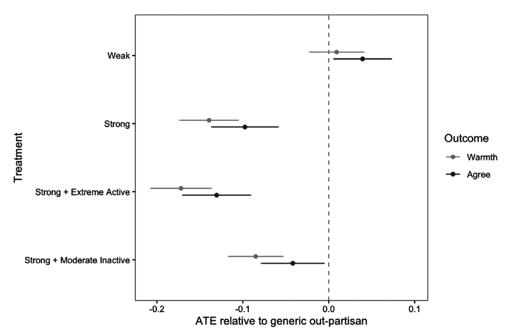

Figure 7: Effects of describing an out-partisan as weak or strong, extreme and active, or moderate and inactive, relative to a generic out-partisan, on warmth (grey) and perceived policy agreement (black). *Source:* Orr et al. (2023), Figure 1.

- A **strong** out-partisan is rated colder
- And seen as **disagreeing** more, almost in proportion
- Even when described as **moderate** and **inactive**
- Branded positions also shift perceived party, other policies, race and religion

## Agreement against loyalty

Table 5: Mean feeling thermometer (0 to 100) among partisans who disagree with their own party on the issue shown. Marriage and neighbour items show the same pattern. *Source:* Orr et al. (2023), Table 1.

| Evaluating | Agrees with me | Disagrees with me | Difference |
| --- | --- | --- | --- |
| A copartisan | 72.7 (disloyal) | 57.1 (loyal) | **15.6** |
| An out-partisan | 66.5 (loyal) | 51.7 (disloyal) | **14.8** |

## Conclusion

- Strongly suggestive evidence that people care about **policy agreement**
- Little convincing evidence that they care about identity or loyalty **per se**
- Perhaps party is how people **summarise** a bundle of positions
- Future designs should check whether an identity treatment also moves **perceived policy**

# Discussion

## What would settle it?

Table 6: The same evidence, two readings.

|  | Dias and Lelkes (2022) | Orr et al. (2023) |
| --- | --- | --- |
| Branded positions shrink the party effect more | Because they **signal identity** | Because they say **more about policy** |
| Disloyal positions shrink it most | People punish **disloyalty** | Disloyalty also signals **other positions** |
| Verdict | Identity is the principal mechanism | Policy matters, identity is not shown |

- Is an “unbranded” issue ever free of party?
- Is wanting loyalty to the party line itself a **policy** preference?
- If party is a summary of policy, is the question still meaningful?

# Wrap-up

## Recap: takeaways

- Complex identities should lower bias, and sorting goes with more AP within countries and persons
- AP is warmth toward one’s own side and dislike of the other, but **why**?
- Party and policy **signal each other**, so the two accounts predict the same data
- Dias and Lelkes: branded positions work by signalling **identity**, so identity is the main channel
- Orr et al.: the same result follows from **policy alone**, and agreement beats loyalty when the two conflict

## Recap: learning goals

**Session 07, goal 4. Social identity complexity**

- Intersection, dominance, compartmentalization, merger: the more inclusive, the less bias

**Goal 1. The two positions**

- Party over policy: they are them, evidence from branded versus unbranded and from disloyalty
- Policy over party: they disagree with me, evidence from policy information and from agreement against loyalty

**Goal 2. Why identity and policy are hard to separate**

- A party label signals positions, and a position signals party and loyalty, so every treatment moves both

**Goal 3. What would distinguish them**

- A treatment that moves perceived identity but not perceived policy, or the reverse, and both papers show how rarely that holds

## Next session

- **Session 09: Consequences of affective polarization for democracy**
- Today we asked what AP is about, next we ask what it does
- Which of the alleged harms hold up?
- Core reading: Harteveld et al. (2026) and Janssen and Turkenburg (2024)

## References

Dias, Nicholas, and Yphtach Lelkes. 2022. “The Nature of Affective Polarization: Disentangling Policy Disagreement from Partisan Identity.” *American Journal of Political Science* 66 (3): 775–90. https://doi.org/10.1111/ajps.12628.

Harteveld, Eelco. 2021. “Ticking All the Boxes? A Comparative Study of Social Sorting and Affective Polarization.” *Electoral Studies* 72: 102337. https://doi.org/10.1016/j.electstud.2021.102337.

Harteveld, Eelco, Lars Erik Berntzen, Andrej Kokkonen, Haylee Kelsall, Jonas Linde, and Stefan Dahlberg. 2026. “The (Alleged) Consequences of Affective Polarization: A Survey Experiment in Nine Democracies.” *European Journal of Political Research*, 1–19. https://doi.org/10.1017/S1475676526101273.

Janssen, Lisa, and Emma Turkenburg. 2024. “Breaking Free from Linear Assumptions: Unravelling the Relationship Between Affective Polarization and Democratic Support.” *European Journal of Political Research* 64: 1465–2479. https://doi.org/10.1111/1475-6765.12725.

Mason, Lilliana. 2016. “A Cross-Cutting Calm: How Social Sorting Drives Affective Polarization.” *Public Opinion Quarterly* 80 (S1): 351–77. https://doi.org/10.1093/poq/nfw001.

Orr, Lilla V., Anthony Fowler, and Gregory A. Huber. 2023. “Is Affective Polarization Driven by Identity, Loyalty, or Substance?” *American Journal of Political Science* 67 (4): 948–62. https://doi.org/10.1111/ajps.12796.

Orr, Lilla V., and Gregory A. Huber. 2020. “The Policy Basis of Measured Partisan Animosity in the United States.” *American Journal of Political Science* 64 (3): 569–86. https://doi.org/10.1111/ajps.12498.

Roccas, Sonia, and Marilynn B. Brewer. 2002. “Social Identity Complexity.” *Personality and Social Psychology Review* 6 (2): 88–106. https://doi.org/10.1207/S15327957PSPR0602_01.